# HOTOSM TM Project 8301 validation

This notebook performs basic validation of data in the HOTOSM Taskin Manager Project #8301

OSM data export used for analysis is available at:

```
https://export.hotosm.org/en/v3/exports/4d19a6bd-949d-48bc-8265-352c21468410
```

```
latest script run: 2020-10-13 15:54:49.202715 UTC
```

# Latest data export status

```
Export tool info
================
{
  "uid": "4d19a6bd-949d-48bc-8265-352c21468410",
  "name": "HOTOSM-TM-project-8301-validation-data",
  "description": "Data export for HOTOSM tasking manager project 8301 automated validation. Includes nodes with place tag",
  "osma_link": "http://osm-analytics.org/#/show/bbox:-73.9811021079999,-15.4582882329999,-70.3450719799999,-11.212293479/buildings/recency",
  "export_formats": [
    "geopackage",
    "osm_pbf",
    "shp"
  ]
}
Latest run info
===============
{
  "uid": "6dfcf9fb-b33d-4e4a-837d-103f82d8de5f",
  "started_at": "2020-10-13T15:43:08.072031Z",
  "status": "COMPLETED"
}
```

# Numbers of non-null values in each field

Informational values for convenience. Lists shows the total number or different unique values for each key in the dataset.

```
osm_id        2499
note             0
name          2401
ele            220
fixme          186
FIXME_1          0
comment          0
source         513
population      57
ELE_1            0
place         2499
descriptio       2
NAME_1           0
geometry      2499
dtype: int64
```

# All different *place* key values

Manually sanity-check that the list below only has allowed values. It is the list of all values used in the AOI.

```
['city' 'suburb' 'village' 'town' 'hamlet' 'isolated_dwelling'
 'neighbourhood' 'square' 'state' 'region' 'locality' 'farm' 'city_block'
 'fixme: what size habitation ?' 'quarter']
```

# Place Name Possibly Duplicated

Ther *may* be dupliacate names. It is possible for multiple places to have the same name.

This lists *nearby* duplicates by *name*: all points with the same name, what are close by to eachother.

The figure below also shows the search radius for context.

```
Adjacent points with duplicate name: 116
Adjacency criterion: 0.1 degrees of arc
```

```
adjacent_duplicates.geojson
```

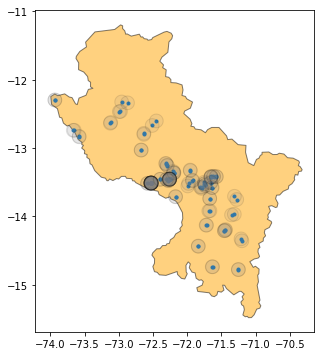

# Place Name Dubious or Missing

All places shall have a 'name' attribute.

This lists all nodes with:

1. no 'name' attribute
2. a 'fixme'='name' attribute indicating name needs to be checked.

```
Places with uncertain name: 98
```

```
name_fixme.geojson
```

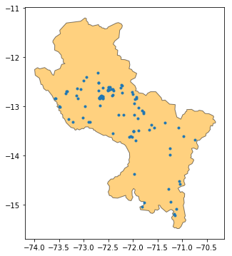

# Generic FIXME Points

There should be 0 nodes with a 'fixme' attribue.

Some are not remotely fixable, though. This lists points where 'fixme' is not 'name', but something more genereic, usually a human-readable string.

```
Places with generic fixme: 0
```

```
generic_fixme.geojson
```

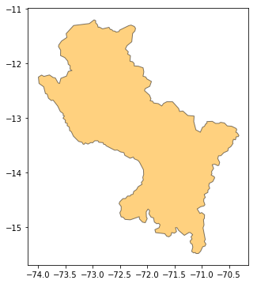

# Uppercase ELE and NAME Fields are Prohibited

There shall be 0 nodes with uppercase ELE or NAME fields.

Original import data had these, but have since been updated. These are unlikely to appear during the project.

```
Points with uppercase ELE or NAME field: 0
```

# Overlapping Nodes are Prohibited

There shall be 0 overlapping nodes.

```
Overlapping nodes: 0
```

### Questions and Feedback

All question, feedback, and development ideas very welcome. Open an Issue in [GitHub repo](https://jarmokivekas.github.io/hotosm-activation-gis-data), or ping @jarmokivekas in the [HOTOSM Slack](https://hotosm.slack.com).